# contiguous array

RenardBao

2019/7/15

## 摘要

`C contiguous`:是指以行為優先的順序（Row-major Order),在記憶體裡面是以行存在一起.  
`Fortran contiguous`:是指以列為優先的順序（Column-major Order),在記憶體裡面是以列存在一起.

## 詳細解說

來源[stackoverflow](https://stackoverflow.com/questions/26998223/what-is-the-difference-between-contiguous-and-non-contiguous-arrays):

contiguous array指的是陣列在記憶體中存放的地址是連續的，提取陣列的下一個值，直接移動到記憶體的下一個地址。

假設一個2維的`array: arr = np.arange(12).reshape(3,4)`。這個陣列的結構是長這樣：

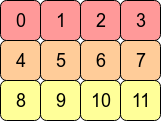

```python
import numpy as np
arr = np.arange(12).reshape(3,4)
arr
```

```
## array([[ 0,  1,  2,  3],
##        [ 4,  5,  6,  7],
##        [ 8,  9, 10, 11]])
```

在電腦記憶體裡，陣列arr實際儲存是像下圖所示：

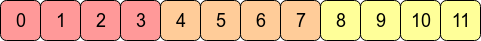

這表示arr是C contiguous的,是指行跟行是連續的被儲存在記憶體.如果我們要從第一列第一個跳到第二列的第一個,那我們得跳過三格(上圖來說,0跳到4得略過1,2,3).

如果我們透過arr.T來轉置矩陣,則`C contiguous`就消失了,取而代之的是`Fortran contiguous`,因為同一列的值不再是相鄰的儲存位置.

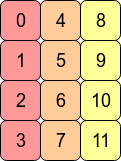

```python
arr.T
```

```
## array([[ 0,  4,  8],
##        [ 1,  5,  9],
##        [ 2,  6, 10],
##        [ 3,  7, 11]])
```

所以對`C contiguous`的陣列來說(Row-major Order),對其以行來進行操作會比對列操作要快上一點.

```python
arr1 =  np.arange(100000000).reshape(10000,10000)

from timeit import timeit

def sum_row():
  np.sum(arr1, axis=1)

t = timeit('sum_row()','from __main__ import sum_row', number=1)
print("sum the rows :",t)
```

```
## sum the rows : 0.039895075648821644
```

```python
def sum_col():
  np.sum(arr1, axis=0)

t2 = timeit('sum_col()','from __main__ import sum_col', number=1)
print("sum the columns :",t2)
```

```
## sum the columns : 0.05128350997021335
```

相反的,對`Fortran contiguous`陣列進行列的操作會比行的操作還快.

```python
arr2 = arr1.T

def sum_row():
  np.sum(arr2, axis=1)
t3 = timeit('sum_row()','from __main__ import sum_row', number=1)
print("sum the rows :",t3)
```

```
## sum the rows : 0.05506617327451263
```

```python
def sum_col():
  np.sum(arr2, axis=0)

t4 = timeit('sum_col()','from __main__ import sum_col', number=1)
print("sum the columns :",t4)
```

```
## sum the columns : 0.0405550750621555
```

那直接對轉置過的矩陣進行shape的操作呢?

```python
arr3 = arr.T
arr3.shape = 12
```

```
## Error in py_call_impl(callable, dots$args, dots$keywords): AttributeError: incompatible shape for a non-contiguous array
##
## Detailed traceback:
##   File "<string>", line 1, in <module>
```

ERROR:`AttributeError: incompatible shape for a non-contiguous array`

因為numpy要將arr.T的結構弄成這樣:

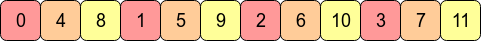

直接設置shape,其必須是`C contiguous`,numpy幾乎都是運行以行優先.  
所以有兩種方法可以達到`arr.T`的一維展開:

- `arr3.reshape(12)`
- `arr3.flatten('C')`

numpy.ravel()是也能達到一樣的效果,不過這邊要注意的是其回傳的是copy,除非`type = 'F'`.

```python
arr3.reshape(12)
```

```
## array([ 0,  4,  8,  1,  5,  9,  2,  6, 10,  3,  7, 11])
```

```python
arr3.flatten('C')
```

```
## array([ 0,  4,  8,  1,  5,  9,  2,  6, 10,  3,  7, 11])
```

```python
print('the flags of arr3.ravel("C")\n',
arr3.ravel('C').flags)
```

```
## the flags of arr3.ravel("C")
##    C_CONTIGUOUS : True
##   F_CONTIGUOUS : True
##   OWNDATA : True
##   WRITEABLE : True
##   ALIGNED : True
##   WRITEBACKIFCOPY : False
##   UPDATEIFCOPY : False
```

```python
print('the flags of arr3.ravel("F")\n', arr3.ravel('F').flags)
```

```
## the flags of arr3.ravel("F")
##    C_CONTIGUOUS : True
##   F_CONTIGUOUS : True
##   OWNDATA : False
##   WRITEABLE : True
##   ALIGNED : True
##   WRITEBACKIFCOPY : False
##   UPDATEIFCOPY : False
```